# Lecture 2

August 2022

## Working with data

- In your career, you will have to deal with **data**.
- It can take the form of sparse information *(clients, patients, surveys, etc)*,
- Or large pieces of information, with or without a time component *(stock price, consumer behavior, social media clicks, etc)*.
- As a finance person, your goals will embed the following to make more informed decisions (hopefully):
  1. Find data.
  2. Correct data.
  3. Input data.
  4. Describe data.
  5. Exploit data.

\(\rightarrow\) We treat all these points in this lecture.

## Why not working with `Excel`?

[figure not shown]

## Why not working with `Excel`?

What are the reasons for not using `Excel`?

1. It has limited flexibility for tuned operations (histograms for instance).
2. It can be fine-tuned with `VBA`, which is a different and somewhat inefficient language.
3. Applying a complex operation on many rows of data proved complicated without `VBA`.
4. It uses **a lot** of RAM with stupid options like auto-computation.
5. It is more efficient to use the same software for data cleaning and analysis.
6. Formulas in `Excel` are ugly (try putting `IF` in `IF` and re-read your formula on the top of your spreadsheet. I guarantee errors.)
7. It has limited data content: 1,048,576 rows (\(2^{20}\)) and 16,384 columns (\(2^{14}\)) \(\Longrightarrow\) No more than 17,179,869,184 entries (this may seem a lot but can prove nonetheless limited).
8. It has limited digit precision.
9. Basic plotting options are **ugly**.
10. You can’t track how people transformed the data!

## Why starting with `Excel` still makes sense

- The main advantage of `Excel` is that it’s **WYSIWYG** *[what you see is what you get]*.
- This is the easiest representation of data to deal with since you can directly read an entry.
- You can directly **visualize the structure of the data**.
- This will help you design your code better.

Panel data structure example:

- A **panel** structure is when you observe \(m\) *characteristics* for \(n\) *individuals* over \(T\) *periods*.
- You can represent it mostly two different ways:
  - [ time \(\times\) ( characteristics & individuals)] \(\Longleftrightarrow\) matrix of size \((T\times nm)\)
  - [( individuals & time) \(\times\) characteristics] \(\Longleftrightarrow\) matrix of size \((nT \times (m+1))\) (time is a variable)

## Panel data structure: example

- Let us look at the S&P500 stock data during 2020.

```python
import yfinance as yf

assets = ['TSLA', 'MSFT', 'META']
prices =  yf.download(assets,
                      start='2020-01-01',
                      end='2020-12-31',
                      progress=False)
#prices.head(2)
list(prices.columns.values)
```

```
## [('Adj Close', 'META'), ('Adj Close', 'MSFT'), ('Adj Close', 'TSLA'), ('Close', 'META'), ('Close', 'MSFT'), ('Close', 'TSLA'), ('High', 'META'), ('High', 'MSFT'), ('High', 'TSLA'), ('Low', 'META'), ('Low', 'MSFT'), ('Low', 'TSLA'), ('Open', 'META'), ('Open', 'MSFT'), ('Open', 'TSLA'), ('Volume', …
```

```python
prices.columns.droplevel(1).drop_duplicates()
```

```
## Index(['Adj Close', 'Close', 'High', 'Low', 'Open', 'Volume'], dtype='object')
```

## Panel data structure: example

- Let us look at the S&P500 stock data during 2020.

```python
prices.head(5)
```

```
##              Adj Close                         ...    Volume
##                   META        MSFT       TSLA  ...      META      MSFT       TSLA
## Date                                           ...
## 2020-01-02  209.779999  156.592010  86.052002  ...  12077100  22622100   47660500
## 2020-01-03  208.669998  154.642166  88.601997  ...  11188400  21116200   88892500
## 2020-01-06  212.600006  155.041870  90.307999  ...  17058900  20813700   50665000
## 2020-01-07  213.059998  153.628250  93.811996  ...  14912400  21634100   89410500
## 2020-01-08  215.220001  156.075302  98.428001  ...  13475000  27746500  155721500
##
## [5 rows x 18 columns]
```

```python
prices.shape
```

```
## (252, 18)
```

- The choice here is [ time \(\times\) ( characteristics & individuals)]

## What we do in this lecture

In this lecture we:

1. Learn how to **load data** from `Excel` to `Python`.
2. Learn **data structures** and how to shape data with respect to our goal.
3. Learn how to deal with **missing data**.
4. Learn how to **describe data** with simple statistics.
5. Learn how to identify **outliers**.
6. Learn how to create **new variables**.

## Dealing with data frames

## Preliminary: `pandas` package

- `Python` is originally equipped to compute.
- It is not as efficient as `Excel` to **create** data.
- However, it is more efficient to perform computations.
- We need to be able to import data from elsewhere to `Python`.
- `pandas` is the package that we need!
- Documentation available [here](http://pandas.pydata.org/docs/user_guide/index.html#user-guide)

```python
import pandas as pd
```

## `pandas` objects

- `Series`: individual series of observations.

```python
my_series = pd.Series([1, 3, 5, np.nan, 6, 8])
print(my_series)
```

```
## 0    1.0
## 1    3.0
## 2    5.0
## 3    NaN
## 4    6.0
## 5    8.0
## dtype: float64
```

- `date_range`: essentially a vector of dates

```python
my_dates = pd.date_range("20130101", periods=6)
print(my_dates)
```

```
## DatetimeIndex(['2013-01-01', '2013-01-02', '2013-01-03', '2013-01-04',
##                '2013-01-05', '2013-01-06'],
##               dtype='datetime64[ns]', freq='D')
```

## `pandas` objects

- `DataFrame`: the most important object. Combines dates and series!

```python
df = pd.DataFrame(np.random.randn(6, 4), index=my_dates, columns=list("ABCD"))
df
```

```
##                    A         B         C         D
## 2013-01-01  1.153390  0.510331  0.918271  1.356835
## 2013-01-02 -0.060675  0.039619  0.626923  0.393700
## 2013-01-03  0.339287 -0.571882  2.102990 -2.241397
## 2013-01-04  1.635909 -0.567590 -1.130645  0.475360
## 2013-01-05  0.559706  0.802252 -0.382540 -0.329580
## 2013-01-06 -1.037048 -1.185737 -1.018382 -0.082644
```

- You can directly create `DataFrame` objects with `pd.DataFrame({})` and pass it a dictionary.
- This is unlikely to be super useful…

## `DataFrames`: further knowledge

- `DataFrames` can contain several variable types, as dictionaries.
- This is likely to happen in practice:
  - *age* is numerical.
  - *gender* is categorical.
  - *fund name* is a bunch of strings.
- You can explore variable types with `dtypes`

```python
df.dtypes
```

```
## A    float64
## B    float64
## C    float64
## D    float64
## dtype: object
```

## `DataFrames`: further knowledge

- Accessing `DataFrames` elements can be done in several ways.
- Typically, you want to observe a subset of variables, or a subset of dates, or both.

```python
# Seeing the top 3 lines of DataFrame
df.head(3)
```

```
##                    A         B         C         D
## 2013-01-01  1.153390  0.510331  0.918271  1.356835
## 2013-01-02 -0.060675  0.039619  0.626923  0.393700
## 2013-01-03  0.339287 -0.571882  2.102990 -2.241397
```

```python
# Seeing the bottom 3 lines of DataFrame
df.tail(3)
```

```
##                    A         B         C         D
## 2013-01-04  1.635909 -0.567590 -1.130645  0.475360
## 2013-01-05  0.559706  0.802252 -0.382540 -0.329580
## 2013-01-06 -1.037048 -1.185737 -1.018382 -0.082644
```

## `DataFrames`: further knowledge

- Selecting a particular subset

```python
df["A"]
```

```
## 2013-01-01    1.153390
## 2013-01-02   -0.060675
## 2013-01-03    0.339287
## 2013-01-04    1.635909
## 2013-01-05    0.559706
## 2013-01-06   -1.037048
## Freq: D, Name: A, dtype: float64
```

```python
df[0:2]
```

```
##                    A         B         C         D
## 2013-01-01  1.153390  0.510331  0.918271  1.356835
## 2013-01-02 -0.060675  0.039619  0.626923  0.393700
```

## `DataFrames`: further knowledge

- Selecting rows and columns based on indices

```python
df.loc["20130102":"20130103", ["A","C"]]
```

```
##                    A         C
## 2013-01-02 -0.060675  0.626923
## 2013-01-03  0.339287  2.102990
```

- Selecting all rows but a subset of columns

```python
df.loc[:, ["A","C"]]
```

```
##                    A         C
## 2013-01-01  1.153390  0.918271
## 2013-01-02 -0.060675  0.626923
## 2013-01-03  0.339287  2.102990
## 2013-01-04  1.635909 -1.130645
## 2013-01-05  0.559706 -0.382540
## 2013-01-06 -1.037048 -1.018382
```

## `DataFrames`: further knowledge

- Selecting rows and columns based on positions

```python
df.iloc[1:3, [0,2]]
```

```
##                    A         C
## 2013-01-02 -0.060675  0.626923
## 2013-01-03  0.339287  2.102990
```

- Selecting based on conditions

```python
df[df["A"] > 0]
```

```
##                    A         B         C         D
## 2013-01-01  1.153390  0.510331  0.918271  1.356835
## 2013-01-03  0.339287 -0.571882  2.102990 -2.241397
## 2013-01-04  1.635909 -0.567590 -1.130645  0.475360
## 2013-01-05  0.559706  0.802252 -0.382540 -0.329580
```

## Training with Data Frames:

Let’s do an exercise:

1. Create a `DataFrame` panda object containing all dates from 2020-01-01 to 2020-12-31, two columns named `TSX` and `SPX`, and random content using `np.random.randn`, and multiply them by \(0.1\). We take these as mimicking returns data.
2. Select and print only the `TSX` data.
3. Select and print the days at which the `TSX` has positive returns. Do the same with `SPX`. How many dates are the same?
4. Select and print the days at which the `TSX` has returns below \(-15\%\). Do the same with `SPX`. How many dates are the same?
5. Assume you hold a 50/50 portfolio of both indices. Using a `for` loop, compute the time series of your portfolio value if you start the year with $100 and keep you portfolio fixed.
6. Make that time series the third variable in your `DataFrame`.

## Loading data from external sources

## import/export data

[figure not shown]

## Loading data from `Excel`

- As we mentioned, you will end up going back and forth between `Excel` and `Python`.
- How to load data from `Excel`?
- I downloaded the *popular indicators* from the WorldBank (found [here](http://databank.worldbank.org/indicator/NY.GDP.MKTP.KD.ZG/1ff4a498/Popular-Indicators#))
- I named it `GDP.csv` (in csv format) and `GDP.xlsx` (in Excel format).

```python
# Loading data from .csv files
Indicators = pd.read_csv("GDP.csv")
Indicators
```

```
##                                  Series Name  ... 2015 [YR2015]
## 0                          Population, total  ...      34413603
## 1                          Population, total  ...       2880703
## 2                          Population, total  ...      39728020
## 3                          Population, total  ...         55806
## 4                          Population, total  ...         77993
## ...                                      ...  ...           ...
## 11062  Inflation, consumer prices (annual %)  ...            ..
## 11063  Inflation, consumer prices (annual %)  ...   1.431611458
## 11064  Inflation, consumer prices (annual %)  ...            ..
## 11065  Inflation, consumer prices (annual %)  ...   10.11059289
## 11066  Inflation, consumer prices (annual %)  ...  -2.430968424
##
## [11067 rows x 20 columns]
```

## Loading data from `Excel`

- for the `.xslx` file:

```python
# Loading data from .xlsx files
# You need to install library "openpyxl" beforehand...
Indicators = pd.read_excel("GDP.xlsx", "Data", index_col=None,
  na_values=["NA"], engine = 'openpyxl')
Indicators
```

```
##                                  Series Name  ... 2015 [YR2015]
## 0                          Population, total  ...      34413603
## 1                          Population, total  ...       2880703
## 2                          Population, total  ...      39728020
## 3                          Population, total  ...         55806
## 4                          Population, total  ...         77993
## ...                                      ...  ...           ...
## 11062  Inflation, consumer prices (annual %)  ...            ..
## 11063  Inflation, consumer prices (annual %)  ...       1.43161
## 11064  Inflation, consumer prices (annual %)  ...            ..
## 11065  Inflation, consumer prices (annual %)  ...       10.1106
## 11066  Inflation, consumer prices (annual %)  ...      -2.43097
##
## [11067 rows x 20 columns]
```

## Writing data to `Excel`

- If you perform significant transformations that take time, you might want to save your data.
- You can do so with `Excel`.
- Saving data in `.csv`

```python
# Saving data in .csv files
Indicators.to_csv("GDP_2.csv")

# Saving data in .xlsx files
Indicators.to_excel("GDP_2.xlsx", "Data")
```

- You can of course indicate a more complete path, otherwise it saves in your current environment.
- Last, you can also load data directly from the internet when they allow for an **API**.
- This is what we did with Yahoo finance data.
- These are usually dealt with on a case by case basis with a particular library.

## Missing data

## World indicators data

- Let us see what is inside our Worldbank data.

```python
Indicators.columns
```

```
## Index(['Series Name', 'Series Code', 'Country Name', 'Country Code',
##        '2000 [YR2000]', '2001 [YR2001]', '2002 [YR2002]', '2003 [YR2003]',
##        '2004 [YR2004]', '2005 [YR2005]', '2006 [YR2006]', '2007 [YR2007]',
##        '2008 [YR2008]', '2009 [YR2009]', '2010 [YR2010]', '2011 [YR2011]',
##        '2012 [YR2012]', '2013 [YR2013]', '2014 [YR2014]', '2015 [YR2015]'],
##       dtype='object')
```

- We directly detect that this is a panel data, where:
  - time is in the columns.
  - individuals are countries and are in rows.
  - characteristics are the different types of series.
- Time is **annual** and runs from 2000 to 2015.

## World indicators data

- Which kind of countries do we have?

```python
Indicators["Country Name"].drop_duplicates("first")
```

```
## 0                Afghanistan
## 1                    Albania
## 2                    Algeria
## 3             American Samoa
## 4                    Andorra
##                ...
## 212    Virgin Islands (U.S.)
## 213       West Bank and Gaza
## 214              Yemen, Rep.
## 215                   Zambia
## 216                 Zimbabwe
## Name: Country Name, Length: 217, dtype: object
```

## World indicators data

- Which kind of variables do we have?

```python
Indicators["Series Name"].drop_duplicates("first")
```

```
## 0                                        Population, total
## 217                           Population growth (annual %)
## 434                                  Surface area (sq. km)
## 651      Poverty headcount ratio at national poverty li...
## 868                        GNI, Atlas method (current US$)
## 1085            GNI per capita, Atlas method (current US$)
## 1302                    GNI, PPP (current international $)
## 1519         GNI per capita, PPP (current international $)
## 1736                       Income share held by lowest 20%
## 1953               Life expectancy at birth, total (years)
## 2170              Fertility rate, total (births per woman)
## 2387     Adolescent fertility rate (births per 1,000 wo...
## 2604     Contraceptive prevalence, any methods (% of wo...
## 2821     Births attended by skilled health staff (% of ...
## 3038       Mortality rate, under-5 (per 1,000 live births)
```

[output cut: 37 more lines]

## World indicators data

- How many variables do we have?

```python
Indicators["Series Name"].drop_duplicates("first").shape
```

```
## (51,)
```

- We have 51 indicators for 217 countries, or 11,067 observations.
- Not all variables are equally informed though!

```python
ZWE_df = Indicators.loc[Indicators["Country Name"]=="Zimbabwe", :]
ZWE_df_school = ZWE_df[ZWE_df["Series Name"]=="School enrollment, secondary (% gross)"]
ZWE_df_school
```

```
##                                  Series Name  ... 2015 [YR2015]
## 4122  School enrollment, secondary (% gross)  ...            ..
##
## [1 rows x 20 columns]
```

- data seems to be missing!

## World indicators data

- Let us look at that variable

```python
df_school = Indicators[Indicators["Series Name"]=="School enrollment, secondary (% gross)"]
df_school.loc[:, ["Country Name", "2015 [YR2015]"]].head(10)
```

```
##              Country Name 2015 [YR2015]
## 3906          Afghanistan       51.6699
## 3907              Albania       97.3885
## 3908              Algeria            ..
## 3909       American Samoa            ..
## 3910              Andorra            ..
## 3911               Angola            ..
## 3912  Antigua and Barbuda        108.23
## 3913            Argentina       106.946
## 3914              Armenia       86.0059
## 3915                Aruba            ..
```

- data seems to be missing!

## The problem of missing data

- This is a **standard issue** with data work: data is unevenly balanced.
- Why is this a problem?
  - You want to compute the average schooling across 217 countries.
  - You can do it for each year.
  - What if some important countries are missing? Incomplete picture.
  - Some may even be appearing and disappearing.
  - Problems may even get worse for **sums** instead of **means**.
- Here the `NA` are coded with `..` which is totally non-standard.
- We replace them by standard `NA`.

```python
Indicators[Indicators == ".."] = np.nan
# Alternative: Indicators.replace("..", np.nan)
df_school = Indicators[Indicators["Series Name"]=="School enrollment, secondary (% gross)"]
df_school.loc[:, ["Country Name", "2015 [YR2015]"]].head(5)
```

```
##         Country Name 2015 [YR2015]
## 3906     Afghanistan       51.6699
## 3907         Albania       97.3885
## 3908         Algeria           NaN
## 3909  American Samoa           NaN
## 3910         Andorra           NaN
```

## The problem of missing data

[figure not shown]

## The problem of missing data

- What does `NA` do in a standard operation?

```python
5 + np.nan
```

```
## nan
```

- `NA` soak up any numerical value, so they are easy to detect!
- **BUT**, most functions automatically **throw them out** or **treat them as zeros**!

```python
df_school.loc[:, ["2015 [YR2015]"]].mean()
```

```
## 2015 [YR2015]    86.816233
## dtype: float64
```

## Detecting missing data

- Detection through `isna`

```python
df_school.loc[:, ["2015 [YR2015]"]].isna()
```

```
##       2015 [YR2015]
## 3906          False
## 3907          False
## 3908           True
## 3909           True
## 3910           True
## ...             ...
## 4118           True
## 4119          False
## 4120           True
## 4121           True
## 4122           True
##
## [217 rows x 1 columns]
```

## Detecting missing data

- Which countries have `NA`?

```python
school_2015 = df_school.loc[:, ["Country Name", "2015 [YR2015]"]]
NA_countries = school_2015.loc[school_2015["2015 [YR2015]"].isna() == True,"Country Name"]
NA_countries
```

```
## 3908                  Algeria
## 3909           American Samoa
## 3910                  Andorra
## 3911                   Angola
## 3915                    Aruba
##                 ...
## 4117                  Vietnam
## 4118    Virgin Islands (U.S.)
## 4120              Yemen, Rep.
## 4121                   Zambia
## 4122                 Zimbabwe
## Name: Country Name, Length: 75, dtype: object
```

[You can print them all with `print(NA_countries.to_string())`]

## What can you do with missing data?

- First, you **have to** know how much missing data there is, and where.
  - The amount of missing data could indicate that there indeed exists no data, mistakes in data collection, value has been erased by a previous user, or any type of problem.
  - Think about daily stock data, and holidays.
- Then, you essentially have 2 solutions: **drop**, or **input**
  - **drop** means you’ll be dropping all missing observations from your data. This can lead you to suppress entire countries, characteristics, or time periods.
  - **input** is a more iteresting approach, where you replace the missing data by an educated guess.
  - This is hard, method-dependent, and likely to be wrong.

## Deleting missing data

- In case you really want to (I wouldn’t), you can delete rows and columns where there are `NA`.

```python
# Deleting rows where there are at least one missing data
Indicators.dropna(axis = 0)
```

```
##                                  Series Name  ... 2015 [YR2015]
## 0                          Population, total  ...      34413603
## 1                          Population, total  ...       2880703
## 2                          Population, total  ...      39728020
## 3                          Population, total  ...         55806
## 4                          Population, total  ...         77993
## ...                                      ...  ...           ...
## 11057  Inflation, consumer prices (annual %)  ...       8.66627
## 11059  Inflation, consumer prices (annual %)  ...       2.48327
## 11061  Inflation, consumer prices (annual %)  ...      0.631201
## 11063  Inflation, consumer prices (annual %)  ...       1.43161
## 11065  Inflation, consumer prices (annual %)  ...       10.1106
##
## [6455 rows x 20 columns]
```

## Deleting missing data

```python
# Deleting columns where there are at least one missing data
Indicators.dropna(axis = 1)
```

```
##                                  Series Name  ... Country Code
## 0                          Population, total  ...          AFG
## 1                          Population, total  ...          ALB
## 2                          Population, total  ...          DZA
## 3                          Population, total  ...          ASM
## 4                          Population, total  ...          AND
## ...                                      ...  ...          ...
## 11062  Inflation, consumer prices (annual %)  ...          VIR
## 11063  Inflation, consumer prices (annual %)  ...          PSE
## 11064  Inflation, consumer prices (annual %)  ...          YEM
## 11065  Inflation, consumer prices (annual %)  ...          ZMB
## 11066  Inflation, consumer prices (annual %)  ...          ZWE
##
## [11067 rows x 4 columns]
```

## Deleting missing data

[figure not shown]

## Training to detect NAs

Practice with `pandas`

1. Download and import the *popular indicators* from the WorldBank (found [here](http://databank.worldbank.org/indicator/NY.GDP.MKTP.KD.ZG/1ff4a498/Popular-Indicators#)).
2. Transform all missing observations into `NA`.
3. Select the following variables:
   - `Life expectancy at birth, total (years)`
   - `Fertility rate, total (births per woman)`
   - `CO2 emissions (metric tons per capita)`
   - `Total debt service (% of GNI)`
4. Compute the number of missing observations for each year.
5. Using `.groupby("Country Code")`, compute the number of missing observations per country per year. Which countries would you drop from the analysis?

## Describing data

## What’s in your data?

- First step is always to check for missing data.
- Second step is to **know what you are observing exactly**.
- We have already seen a bit of that beforehand (number of characteristics, individuals, and time).
- We need to investigate more.
- **READ THE METADATA** \(\Longrightarrow\) it’ll tell you a description of the variables and their units.
- Once this is done, we can start the investigation.

## What’s in your data?

- How many variables do you observe per year? What are the distributions?

```python
Indicators.iloc[:,4:20].describe()
```

```
##         2000 [YR2000]  2001 [YR2001]  ...  2014 [YR2014]  2015 [YR2015]
## count          7460.0         7334.0  ...         8180.0         7887.0
## unique         6704.0         6863.0  ...         7434.0         7138.0
## top             100.0            0.1  ...            7.0            7.0
## freq            213.0           41.0  ...           38.0           35.0
##
## [4 rows x 16 columns]
```

- We have one problem here: `Python` has not recognized that the values are numbers, they are treated as *objects*.

```python
Indicators["2000 [YR2000]"].dtype
```

```
## dtype('O')
```

## What’s in your data?

- Let’s transform the year 2000 into a numerical vector

```python
Indicators["2000 [YR2000]"] = pd.to_numeric(Indicators["2000 [YR2000]"])
Indicators["2000 [YR2000]"].dtype
```

```
## dtype('float64')
```

- Let’s do this for every year of data

```python
column_names = Indicators.columns
for name in column_names[4:20]:
  Indicators[name] = pd.to_numeric(Indicators[name])
Indicators.dtypes
```

```
## Series Name       object
## Series Code       object
## Country Name      object
## Country Code      object
## 2000 [YR2000]    float64
## 2001 [YR2001]    float64
## 2002 [YR2002]    float64
## 2003 [YR2003]    float64
## 2004 [YR2004]    float64
## 2005 [YR2005]    float64
## 2006 [YR2006]    float64
## 2007 [YR2007]    float64
## 2008 [YR2008]    float64
## 2009 [YR2009]    float64
## 2010 [YR2010]    float64
## 2011 [YR2011]    float64
## 2012 [YR2012]    float64
## 2013 [YR2013]    float64
## 2014 [YR2014]    float64
## 2015 [YR2015]    float64
## dtype: object
```

## What’s in your data?

- Let’s try our describe again

```python
Indicators.iloc[:,4:20].describe()
```

```
##        2000 [YR2000]  2001 [YR2001]  ...  2014 [YR2014]  2015 [YR2015]
## count   7.460000e+03   7.334000e+03  ...   8.180000e+03   7.887000e+03
## mean    1.513751e+10   1.627544e+10  ...   3.346946e+10   3.415759e+10
## std     2.426188e+11   2.525027e+11  ...   4.716841e+11   4.911760e+11
## min    -1.627550e+11  -3.735700e+10  ...  -1.728058e+11  -2.093630e+11
## 25%     6.656981e+00   6.264806e+00  ...   6.000000e+00   5.382360e+00
## 50%     5.837948e+01   5.951010e+01  ...   6.033187e+01   5.231245e+01
## 75%     3.702500e+03   4.540000e+03  ...   5.674048e+03   6.035000e+03
## max     1.038367e+13   1.074370e+13  ...   1.805496e+13   1.869601e+13
##
## [8 rows x 16 columns]
```

- We now have indicators of the distributions!

[Reminder: \(q_\alpha\) is such that \(\alpha\)% of observations fall below \(q_\alpha\).]

- This is somewhat uninformative. Why?

## Grouping data elements

- We are mixing together all characteristics!
- Let us try to perform these **summary statistics** across countries, for each year \(\times\) characteristic.

```python
Indicators.groupby("Series Name").describe()
```

```
##                                                    2000 [YR2000]  ... 2015 [YR2015]
##                                                            count  ...           max
## Series Name                                                       ...
## Adolescent fertility rate (births per 1,000 wom...         194.0  ...  1.922200e+02
## Agriculture, forestry, and fishing, value added...         184.0  ...  5.865189e+01
## Births attended by skilled health staff (% of t...         142.0  ...  1.000000e+02
## CO2 emissions (metric tons per capita)                     191.0  ...  3.247057e+01
## Contraceptive prevalence, any methods (% of wom...          78.0  ...  8.675342e+01
## Electric power consumption (kWh per capita)                140.0  ...  9.100000e+02
## Energy use (kg of oil equivalent per capita)               140.0  ...  1.747889e+04
## Exports of goods and services (% of GDP)                   176.0  ...  2.211966e+02
## External debt stocks, total (DOD, current US$)             116.0  ...  1.333777e+12
## Fertility rate, total (births per woman)                   200.0  ...  7.169000e+00
## Foreign direct investment, net (BoP, current US$)          145.0  ...  1.331628e+11
## Foreign direct investment, net inflows (BoP, cu...         189.0  ...  5.114340e+11
## Forest area (sq. km)                                       210.0  ...  8.149305e+06
## GDP (current US$)                                          197.0  ...  1.823830e+13
## GDP growth (annual %)                                      193.0  ...  2.517640e+01
## GDP per capita (current US$)                               197.0  ...  1.673133e+05
## GNI per capita, Atlas method (current US$)                 179.0  ...  1.011200e+05
## GNI per capita, PPP (current international $)              181.0  ...  1.039100e+05
## GNI, Atlas method (current US$)                            179.0  ...  1.820010e+13
## GNI, PPP (current international $)                         181.0  ...  1.869601e+13
## Gross capital formation (% of GDP)                         166.0  ...  7.940108e+01
## High-technology exports (% of manufactured expo...           0.0  ...  7.847656e+01
## Immunization, measles (% of children ages 12-23...         189.0  ...  9.900000e+01
## Imports of goods and services (% of GDP)                   176.0  ...  1.935083e+02
## Income share held by lowest 20%                             50.0  ...  1.000000e+01
## Industry (including construction), value added ...         180.0  ...  6.136236e+01
## Inflation, GDP deflator (annual %)                         192.0  ...  4.647625e+01
## Inflation, consumer prices (annual %)                      157.0  ...  1.217381e+02
## Life expectancy at birth, total (years)                    201.0  ...  8.427805e+01
## Market capitalization of listed domestic compan...          69.0  ...  1.029426e+03
## Merchandise trade (% of GDP)                               185.0  ...  3.456085e+02
## Military expenditure (% of GDP)                            145.0  ...  1.332567e+01
## Mobile cellular subscriptions (per 100 people)             204.0  ...  3.149218e+02
## Mortality rate, under-5 (per 1,000 live births)            193.0  ...  1.383000e+02
## Net ODA received per capita (current US$)                  144.0  ...  4.473376e+03
## Net barter terms of trade index (2000 = 100)               202.0  ...  2.659189e+02
## Net migration                                                0.0  ...           NaN
## Personal remittances, paid (current US$)                   144.0  ...  6.071900e+10
## Population growth (annual %)                               217.0  ...  5.790591e+00
## Population, total                                          217.0  ...  1.371220e+09
## Poverty headcount ratio at national poverty lin...          19.0  ...  6.560000e+01
## Prevalence of HIV, total (% of population ages ...         122.0  ...  2.890000e+01
## Prevalence of underweight, weight for age (% of...          56.0  ...  3.630000e+01
## Primary completion rate, total (% of relevant a...         127.0  ...  1.142725e+02
## Revenue, excluding grants (% of GDP)                        82.0  ...  1.204934e+02
## School enrollment, primary and secondary (gross...         139.0  ...  1.134040e+00
## School enrollment, secondary (% gross)                     145.0  ...  1.639347e+02
## Start-up procedures to register a business (num...           0.0  ...  2.000000e+01
## Surface area (sq. km)                                      215.0  ...  1.709825e+07
## Total debt service (% of GNI)                              112.0  ...  3.295926e+01
## Water productivity, total (constant 2010 US$ GD...           0.0  ...           NaN
##
## [51 rows x 128 columns]
```

## Grouping data elements

- This is better but we cannot directly perform this stats for across countries/year.
- If we want to use `groupby`, we need to change our data structure!

```python
# Initialize our final object
#----------------------------
Final_data = Indicators.iloc[:,0:5]
# Create a variable "year"
Final_data["year"] = "2000"
# Rename the values
Final_data = Final_data.rename(columns = {"2000 [YR2000]" : "Value"})

# Loop over all remaining years
#------------------------------
for name in column_names[5:20]:
  Temp_data = Indicators.loc[:,['Series Name', 'Series Code',
  'Country Name', 'Country Code', name]]
  Temp_data["year"] = name[0:4]
  Temp_data = Temp_data.rename(columns = {name : "Value"})

  # Concatenate data
  Final_data = pd.concat([Final_data, Temp_data])
```

## Grouping data elements

- Now we can describe our data across countries/year.

```python
Final_data.groupby(["Series Name"]).describe()
```

```
##                                                      Value  ...
##                                                      count  ...           max
## Series Name                                                 ...
## Adolescent fertility rate (births per 1,000 wom...  3104.0  ...  2.171594e+02
## Agriculture, forestry, and fishing, value added...  3029.0  ...  7.904236e+01
## Births attended by skilled health staff (% of t...  1731.0  ...  1.000000e+02
## CO2 emissions (metric tons per capita)              3056.0  ...  4.769993e+01
## Contraceptive prevalence, any methods (% of wom...   679.0  ...  9.600000e+01
## Electric power consumption (kWh per capita)         2114.0  ...  5.479917e+04
## Energy use (kg of oil equivalent per capita)        2261.0  ...  2.212043e+04
## Exports of goods and services (% of GDP)            2952.0  ...  4.332235e+02
## External debt stocks, total (DOD, current US$)      1888.0  ...  1.778391e+12
## Fertility rate, total (births per woman)            3217.0  ...  7.679000e+00
## Foreign direct investment, net (BoP, current US$)   2768.0  ...  1.772770e+11
## Foreign direct investment, net inflows (BoP, cu...  3135.0  ...  7.338265e+11
## Forest area (sq. km)                                3380.0  ...  8.151356e+06
## GDP (current US$)                                   3260.0  ...  1.823830e+13
## GDP growth (annual %)                               3241.0  ...  1.231396e+02
## GDP per capita (current US$)                        3260.0  ...  1.894324e+05
## GNI per capita, Atlas method (current US$)          3031.0  ...  1.219000e+05
## GNI per capita, PPP (current international $)       3025.0  ...  1.324400e+05
## GNI, Atlas method (current US$)                     3031.0  ...  1.820010e+13
## GNI, PPP (current international $)                  3025.0  ...  1.869601e+13
## Gross capital formation (% of GDP)                  2754.0  ...  7.940108e+01
## High-technology exports (% of manufactured expo...  1174.0  ...  7.847656e+01
## Immunization, measles (% of children ages 12-23...  3053.0  ...  9.900000e+01
## Imports of goods and services (% of GDP)            2952.0  ...  4.275765e+02
## Income share held by lowest 20%                     1125.0  ...  1.090000e+01
## Industry (including construction), value added ...  3020.0  ...  8.779689e+01
## Inflation, GDP deflator (annual %)                  3240.0  ...  2.630123e+03
## Inflation, consumer prices (annual %)               2803.0  ...  5.139068e+02
## Life expectancy at birth, total (years)             3207.0  ...  8.541707e+01
## Market capitalization of listed domestic compan...  1141.0  ...  1.254465e+03
## Merchandise trade (% of GDP)                        3060.0  ...  1.170100e+04
## Military expenditure (% of GDP)                     2415.0  ...  3.265567e+01
## Mobile cellular subscriptions (per 100 people)      3275.0  ...  3.149218e+02
## Mortality rate, under-5 (per 1,000 live births)     3088.0  ...  2.277000e+02
## Net ODA received per capita (current US$)           2287.0  ...  4.473376e+03
## Net barter terms of trade index (2000 = 100)        3221.0  ...  4.585745e+02
## Net migration                                        582.0  ...  5.428756e+06
## Personal remittances, paid (current US$)            2704.0  ...  6.071900e+10
## Population growth (annual %)                        3468.0  ...  1.751221e+01
## Population, total                                   3468.0  ...  1.371220e+09
## Poverty headcount ratio at national poverty lin...   717.0  ...  8.330000e+01
## Prevalence of HIV, total (% of population ages ...  1952.0  ...  2.890000e+01
## Prevalence of underweight, weight for age (% of...   529.0  ...  4.950000e+01
## Primary completion rate, total (% of relevant a...  2075.0  ...  1.345425e+02
## Revenue, excluding grants (% of GDP)                1790.0  ...  3.415165e+02
## School enrollment, primary and secondary (gross...  2215.0  ...  1.163180e+00
## School enrollment, secondary (% gross)              2320.0  ...  1.639347e+02
## Start-up procedures to register a business (num...  2200.0  ...  2.100000e+01
## Surface area (sq. km)                               3450.0  ...  1.709825e+07
## Total debt service (% of GNI)                       1852.0  ...  5.967140e+01
## Water productivity, total (constant 2010 US$ GD...   503.0  ...  1.220277e+03
##
## [51 rows x 8 columns]
```

## Grouping data elements

- Now we can perform our operations across countries for each year.

```python
Final_data.groupby(["Series Name", "year"]).describe()
```

```
##                                                          Value  ...
##                                                          count  ...          max
## Series Name                                        year         ...
## Adolescent fertility rate (births per 1,000 wom... 2000  194.0  ...   217.159400
##                                                    2001  194.0  ...   216.354200
##                                                    2002  194.0  ...   215.549000
##                                                    2003  194.0  ...   214.362800
##                                                    2004  194.0  ...   213.176600
## ...                                                        ...  ...          ...
## Water productivity, total (constant 2010 US$ GD... 2011    0.0  ...          NaN
##                                                    2012  174.0  ...  1220.277310
##                                                    2013    0.0  ...          NaN
##                                                    2014    1.0  ...    59.838179
##                                                    2015    0.0  ...          NaN
##
## [816 rows x 8 columns]
```

## Grouping data elements

- Or across years for each country/series pair.

```python
Final_data.groupby(["Series Name", "Country Name"]).describe()
```

```
##                                                                          Value  ...
##                                                                          count  ...         max
## Series Name                                        Country Name                 ...
## Adolescent fertility rate (births per 1,000 wom... Afghanistan            16.0  ...  153.951000
##                                                    Albania                16.0  ...   20.730000
##                                                    Algeria                16.0  ...   11.755600
##                                                    American Samoa          0.0  ...         NaN
##                                                    Andorra                 0.0  ...         NaN
## ...                                                                        ...  ...         ...
## Water productivity, total (constant 2010 US$ GD... Virgin Islands (U.S.)   0.0  ...         NaN
##                                                    West Bank and Gaza      2.0  ...   20.964942
##                                                    Yemen, Rep.             3.0  ...    7.748258
##                                                    Zambia                  3.0  ...   14.642894
##                                                    Zimbabwe                3.0  ...    4.635716
##
## [11067 rows x 8 columns]
```

## Grouping data elements

- You can also perform simple operations

```python
Final_data.groupby(["Series Name"]).mean()
```

```
##                                                            Value
## Series Name
## Adolescent fertility rate (births per 1,000 wom...  5.596632e+01
## Agriculture, forestry, and fishing, value added...  1.198201e+01
## Births attended by skilled health staff (% of t...  8.923212e+01
## CO2 emissions (metric tons per capita)              4.392759e+00
## Contraceptive prevalence, any methods (% of wom...  4.953462e+01
## Electric power consumption (kWh per capita)         4.038277e+03
## Energy use (kg of oil equivalent per capita)        2.509368e+03
## Exports of goods and services (% of GDP)            4.311117e+01
## External debt stocks, total (DOD, current US$)      3.203978e+10
## Fertility rate, total (births per woman)            2.970055e+00
## Foreign direct investment, net (BoP, current US$)  -5.336153e+08
## Foreign direct investment, net inflows (BoP, cu...  9.238150e+09
## Forest area (sq. km)                                1.936816e+05
## GDP (current US$)                                   2.771587e+11
## GDP growth (annual %)                               3.812903e+00
## GDP per capita (current US$)                        1.409407e+04
## GNI per capita, Atlas method (current US$)          1.153259e+04
## GNI per capita, PPP (current international $)       1.557044e+04
## GNI, Atlas method (current US$)                     2.931429e+11
## GNI, PPP (current international $)                  4.097333e+11
## Gross capital formation (% of GDP)                  2.383623e+01
## High-technology exports (% of manufactured expo...  1.057931e+01
## Immunization, measles (% of children ages 12-23...  8.573567e+01
## Imports of goods and services (% of GDP)            4.936052e+01
## Income share held by lowest 20%                     6.641867e+00
## Industry (including construction), value added ...  2.651691e+01
## Inflation, GDP deflator (annual %)                  7.588137e+00
## Inflation, consumer prices (annual %)               6.243083e+00
## Life expectancy at birth, total (years)             6.950555e+01
## Market capitalization of listed domestic compan...  6.644808e+01
## Merchandise trade (% of GDP)                        7.313543e+01
## Military expenditure (% of GDP)                     2.002960e+00
## Mobile cellular subscriptions (per 100 people)      6.585590e+01
## Mortality rate, under-5 (per 1,000 live births)     4.224417e+01
## Net ODA received per capita (current US$)           1.281651e+02
## Net barter terms of trade index (2000 = 100)        1.126721e+02
## Net migration                                      -1.006624e+03
## Personal remittances, paid (current US$)            1.563514e+09
## Population growth (annual %)                        1.425238e+00
## Population, total                                   3.089199e+07
## Poverty headcount ratio at national poverty lin...  2.500781e+01
## Prevalence of HIV, total (% of population ages ...  2.245031e+00
## Prevalence of underweight, weight for age (% of...  1.410076e+01
## Primary completion rate, total (% of relevant a...  8.804940e+01
## Revenue, excluding grants (% of GDP)                2.723547e+01
## School enrollment, primary and secondary (gross...  9.726875e-01
## School enrollment, secondary (% gross)              7.873407e+01
## Start-up procedures to register a business (num...  8.725909e+00
## Surface area (sq. km)                               6.143649e+05
## Total debt service (% of GNI)                       4.147872e+00
## Water productivity, total (constant 2010 US$ GD...  6.453666e+01
```

## Training to perform basic data description

Practice with `pandas`

1. Start back with the worldbank data where `NA` has been treated.
2. Compute the average and standard deviations of the four series across all countries for each year. How have these indicators moved through time? Comment on the heterogeneity across countries (do no forget the missing values!)
3. Compute the same indicators across countries but across years. What is the country with the lowest fertility rate? The one with the highest? What is the country with the most variation in time?
4. Compute the distribution quartiles for each year and variable across countries. For each year/variable pair, identify the country at 25% and 75%. Is there a lot of variation?

## Identifying outliers

## What is an outlier?

- When you’re dealing with data, an outlier is you worst nightmare.
- It’s a value that’s completely **implausible**, because of a mistake or a particular coding of variables that was not clear.
  - Sometimes, missing data is indicated by 99 instead of `NA`.
  - It can be a code for *refused to answer*, which is different from a lack of answer.
  - It can also be a missing or extra (couple) of zeros.
- How to detect them?
  1. Standard statistics and plausibility assessment.
  2. Plots.

## Standard statistics and graphical representation

- Let us focus on 4 different variables for instance.
  - GDP growth,
  - Inflation (consumer prices),
  - Start up procedures to register a business (ratio of population),
  - Income share held by lowest 20%.

```python
# Selecting the variables
Subset_data = Final_data[Final_data["Series Name"].isin(["GDP growth (annual %)",
                          "Inflation, consumer prices (annual %)",
                          "Start-up procedures to register a business (number)",
                          "Population, total",
                          "Income share held by lowest 20%"])]
Subset_data.shape
```

```
## (17360, 6)
```

## Standard statistics and graphical representation

- Let us compute the share of startup as fraction of population

```python
new_variable = Subset_data[Subset_data["Series Name"]=="Start-up procedures to register a business (number)"]
Population = Subset_data.loc[Subset_data["Series Name"]=="Population, total", "Value"]

# Python can only compute operations on DF that have the same indexes to avoid mistakes
# This doesn't really work...
Population.index = new_variable.index
new_variable.loc[:,"Value"] = new_variable.loc[:,"Value"]/Population
```

## Playing with indexing

- Technically, there is a much better solution: playing with **indexing**.

```python
Subset_data.index
```

```
## Int64Index([    0,     1,     2,     3,     4,     5,     6,     7,     8,
##                 9,
##             ...
##             11057, 11058, 11059, 11060, 11061, 11062, 11063, 11064, 11065,
##             11066],
##            dtype='int64', length=17360)
```

```python
# The index will be Country x Year x Series
My_index = pd.MultiIndex.from_frame(Subset_data.loc[:, ["Country Code",
                                                        "year",
                                                        "Series Code"]])

# Correcting the data frame
Subset_data.index = My_index
Subset_data = Subset_data.loc[:, ["Series Name", "Value"]]
Subset_data.index
```

```
## MultiIndex([('AFG', '2000',    'SP.POP.TOTL'),
##             ('ALB', '2000',    'SP.POP.TOTL'),
##             ('DZA', '2000',    'SP.POP.TOTL'),
##             ('ASM', '2000',    'SP.POP.TOTL'),
##             ('AND', '2000',    'SP.POP.TOTL'),
##             ('AGO', '2000',    'SP.POP.TOTL'),
##             ('ATG', '2000',    'SP.POP.TOTL'),
##             ('ARG', '2000',    'SP.POP.TOTL'),
##             ('ARM', '2000',    'SP.POP.TOTL'),
##             ('ABW', '2000',    'SP.POP.TOTL'),
##             ...
##             ('URY', '2015', 'FP.CPI.TOTL.ZG'),
##             ('UZB', '2015', 'FP.CPI.TOTL.ZG'),
##             ('VUT', '2015', 'FP.CPI.TOTL.ZG'),
##             ('VEN', '2015', 'FP.CPI.TOTL.ZG'),
##             ('VNM', '2015', 'FP.CPI.TOTL.ZG'),
##             ('VIR', '2015', 'FP.CPI.TOTL.ZG'),
##             ('PSE', '2015', 'FP.CPI.TOTL.ZG'),
##             ('YEM', '2015', 'FP.CPI.TOTL.ZG'),
##             ('ZMB', '2015', 'FP.CPI.TOTL.ZG'),
##             ('ZWE', '2015', 'FP.CPI.TOTL.ZG')],
##            names=['Country Code', 'year', 'Series Code'], length=17360)
```

## Playing with indexing

- We can now construct our variable more easily

```python
new_variable_num = Subset_data.xs("IC.REG.PROC", level = "Series Code")
new_variable_denom = Subset_data.xs("SP.POP.TOTL", level = "Series Code")

new_variable = new_variable_num["Value"]/new_variable_denom["Value"]
new_variable
```

```
## Country Code  year
## AFG           2000             NaN
## ALB           2000             NaN
## DZA           2000             NaN
## ASM           2000             NaN
## AND           2000             NaN
##                           ...
## VIR           2015             NaN
## PSE           2015    2.341870e-06
## YEM           2015    2.264332e-07
## ZMB           2015    4.408235e-07
## ZWE           2015    7.238696e-07
## Name: Value, Length: 3472, dtype: float64
```

- **Key advantage**: We had the risk beforehand that countries and years would not be matched. Not anymore.

## Joining our data frames

- Now we should join our two pieces of data.

```python
old_index = new_variable.index.to_frame()
old_index.insert(2, "Series Code", "IC.REG.PROC.PCT")
new_variable.index = pd.MultiIndex.from_frame(old_index)

Subset_data = pd.concat([Subset_data, new_variable.to_frame()])
Subset_data
```

```
##                                          Series Name         Value
## Country Code year Series Code
## AFG          2000 SP.POP.TOTL      Population, total  2.077996e+07
## ALB          2000 SP.POP.TOTL      Population, total  3.089027e+06
## DZA          2000 SP.POP.TOTL      Population, total  3.104224e+07
## ASM          2000 SP.POP.TOTL      Population, total  5.781600e+04
## AND          2000 SP.POP.TOTL      Population, total  6.539000e+04
## ...                                              ...           ...
## VIR          2015 IC.REG.PROC.PCT                NaN           NaN
## PSE          2015 IC.REG.PROC.PCT                NaN  2.341870e-06
## YEM          2015 IC.REG.PROC.PCT                NaN  2.264332e-07
## ZMB          2015 IC.REG.PROC.PCT                NaN  4.408235e-07
## ZWE          2015 IC.REG.PROC.PCT                NaN  7.238696e-07
##
## [20832 rows x 2 columns]
```

## Back to statistics!

[figure not shown]

## Back to statistics!

- Let’s plot the distribution of our variables!
- We need the `matplotlib` library

```python
import matplotlib.pyplot as plt
plt.rcParams.update({'font.size': 7})
plt.close("all")

plt.figure();
My_hist = Subset_data.hist(column = "Value", by = Subset_data["Series Name"], bins = 25)
```

## Back to statistics

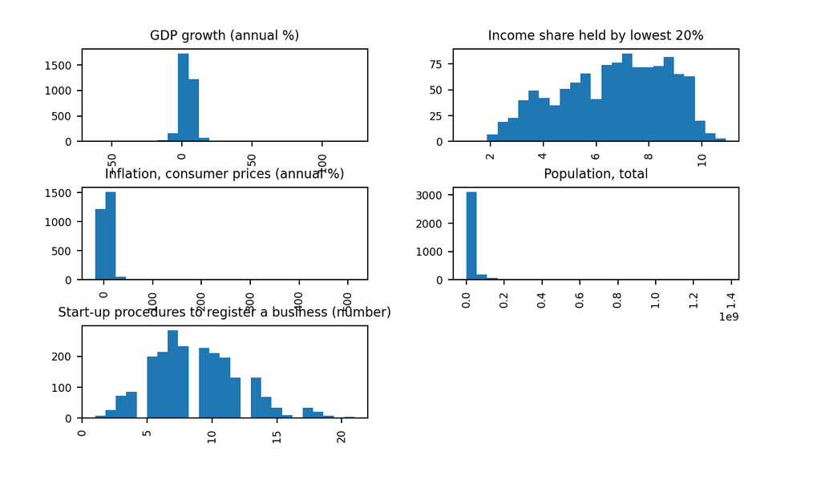

```python
plt.show(My_hist)
```

- Something weird?

## Back to statistics

- Let’s confirm with a boxplot.

```python
# Unstacking the series level to control for the boxplot
data_to_plot = Subset_data.unstack(level = 2).loc[:,"Value"]
data_to_plot["Series"] = 1
data_to_plot.columns = ['CPI (% growth)', 'New Start-Up', 'New Start-Up (%pop)', 'GDP growth', 'Income share', 'Population', 'Series']

plt.figure();
fig, axs = plt.subplots(1,6, sharey=False)
data_to_plot.boxplot(by = "Series", ax = axs)
```

```
## array([<matplotlib.axes._subplots.AxesSubplot object at 0x0000000033AD8588>,
##       dtype=object)
##
```

```python
plt.subplots_adjust(wspace = .7, hspace = .4)
```

## Back to statistics

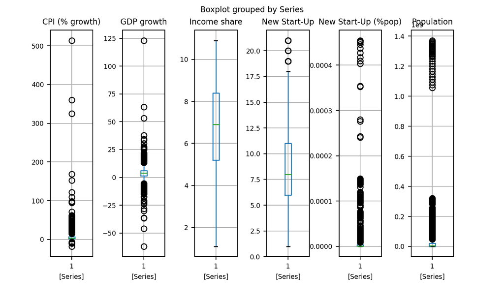

```python
plt.show(fig)
```

- Something weird?

## Back to statistics

- Doing the plot year by year

```python
#Unstacking the series level to control for the boxplot
data_to_plot2 = data_to_plot.reset_index(level = 1) # filling year into a series
data_to_plot2 = data_to_plot2.loc[:,data_to_plot2.columns != "Series"] # Dropping Series

plt.figure();
fig, axs = plt.subplots(3,2, figsize = (9,5), sharey=False)
data_to_plot2.boxplot(by = "year", ax = axs)
```

```
## array([<matplotlib.axes._subplots.AxesSubplot object at 0x0000000033797B38>,
##       dtype=object)
##
```

```python
for ax in fig.axes:
    plt.sca(ax)
    plt.xticks(rotation=45)
```

```
## (array([ 1,  2,  3,  4,  5,  6,  7,  8,  9, 10, 11, 12, 13, 14, 15, 16]), <a list of 16 Text major ticklabel objects>)
## (array([ 1,  2,  3,  4,  5,  6,  7,  8,  9, 10, 11, 12, 13, 14, 15, 16]), <a list of 16 Text major ticklabel objects>)
## (array([ 1,  2,  3,  4,  5,  6,  7,  8,  9, 10, 11, 12, 13, 14, 15, 16]), <a list of 16 Text major ticklabel objects>)
## (array([ 1,  2,  3,  4,  5,  6,  7,  8,  9, 10, 11, 12, 13, 14, 15, 16]), <a list of 16 Text major ticklabel objects>)
## (array([ 1,  2,  3,  4,  5,  6,  7,  8,  9, 10, 11, 12, 13, 14, 15, 16]), <a list of 16 Text major ticklabel objects>)
## (array([ 1,  2,  3,  4,  5,  6,  7,  8,  9, 10, 11, 12, 13, 14, 15, 16]), <a list of 16 Text major ticklabel objects>)
```

```python
plt.subplots_adjust(wspace = .1, hspace = 1)
```

## Back to statistics

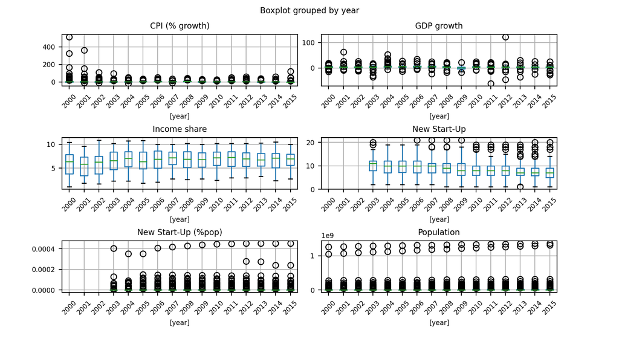

## Time Series plots

- `Matplotlib` is nice but becomes rapidly limited when it comes to various sources of plots.
- In any case, it’s a bit hard to deal with and plots are quite **ugly**.
- Alternative: `plotnine`!
  - This is the adaptation of `ggplot` package in `R` which creates beautiful graphs easily.
  - More help can be found [here](https://realpython.com/ggplot-python/) or [here](https://towardsdatascience.com/how-to-use-ggplot2-in-python-74ab8adec129).
- Installing:

```python
# Installing plotnine using conda
conda install -c conda-forge plotnine
```

## Time Series plots with plotnine

```python
import plotnine as plt9

data_time_series = Subset_data.reset_index()
data_time_series = data_time_series.loc[
  data_time_series["Country Code"].isin(["CAN","USA", "FRA", "CHN"]),:]
# We need to change the type of year from "object" to "numeric" to get lines of time series
data_time_series["year"] = pd.to_numeric(data_time_series["year"])

# Change series name for beautiful printing
data_time_series["Series"] = data_time_series["Series Code"]
data_time_series["Series"].loc[data_time_series["Series"]=="SP.POP.TOTL"] = "Population"
data_time_series["Series"].loc[data_time_series["Series"]=="SI.DST.FRST.20"] = "Income share 20%"
data_time_series["Series"].loc[data_time_series["Series"]=="NY.GDP.MKTP.KD.ZG"] = "GDP groth"
data_time_series["Series"].loc[data_time_series["Series"]=="IC.REG.PROC"] = "startup"
data_time_series["Series"].loc[data_time_series["Series"]=="IC.REG.PROC.PCT"] = "startup (% pop)"
data_time_series["Series"].loc[data_time_series["Series"]=="FP.CPI.TOTL.ZG"] = "Inflation (%)"

my_plot9 = (
  plt9.ggplot(data_time_series)
    + plt9.aes(x = "year", y = "Value")
    + plt9.facet_grid(facets = ('Series','Country Code'), scales = "free")
    + plt9.geom_line()
    + plt9.theme(axis_text_x=plt9.element_text(angle=45),
                 strip_text_y=plt9.element_text(size=5),
                 axis_text_y=plt9.element_text(size=7))
    + plt9.labs(title = "Time Series plot", y = "", x = "")
)
```

## Time Series plots with plotnine

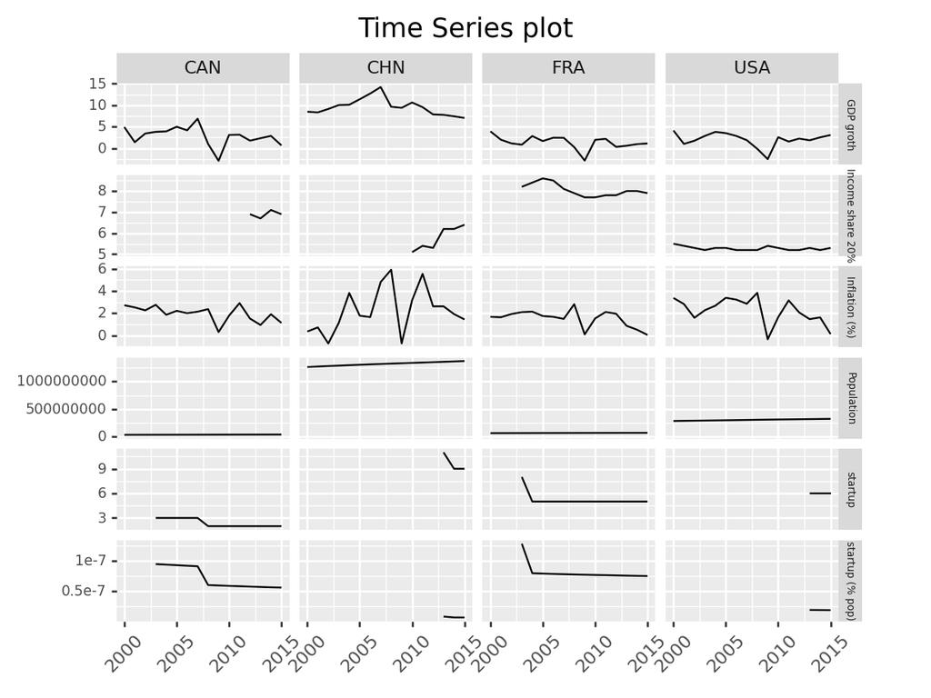

## Time Series plots with plotnine

- You can add options very easily: dark theme

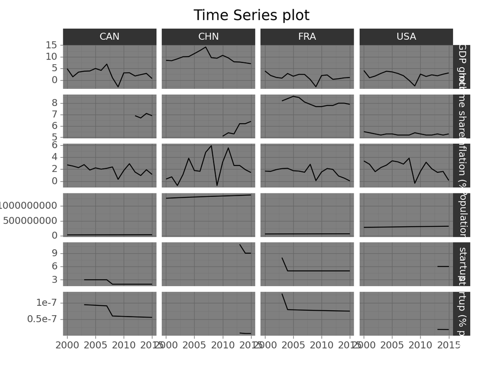

## Time Series plots with plotnine

- You can add options very easily: adding points

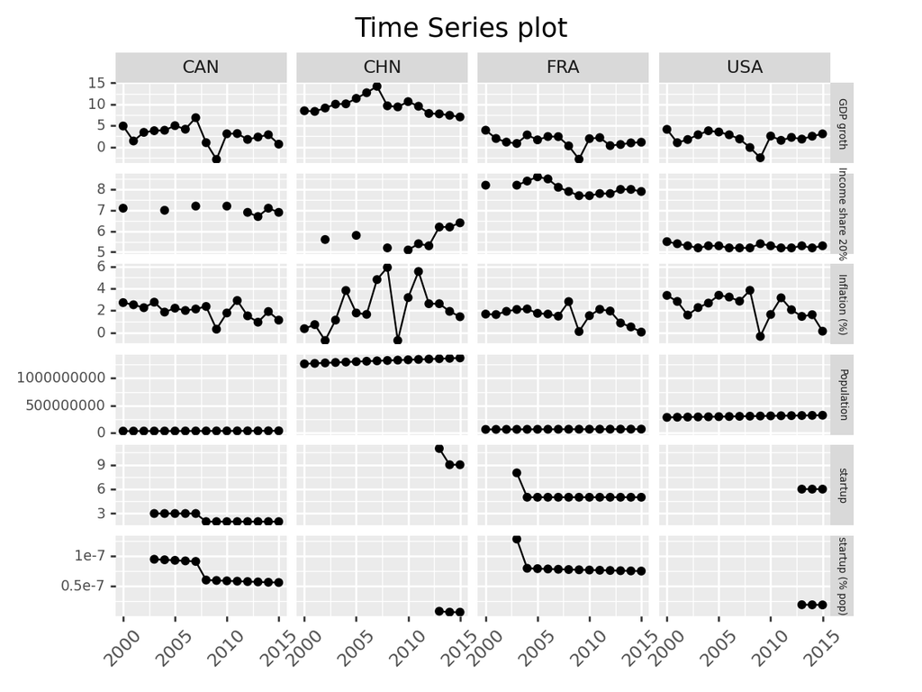

## Time Series plots with plotnine

- Compress one dimension but different colors

```python
(
  plt9.ggplot(data_time_series)
    + plt9.aes(x = "year", y = "Value", colour = "Country Code")
    + plt9.facet_grid(facets = ('Series','.'), scales = "free")
    + plt9.geom_line()
    + plt9.theme(axis_text_x=plt9.element_text(angle=45),
                 strip_text_y=plt9.element_text(size=5),
                 axis_text_y=plt9.element_text(size=7),
                 subplots_adjust={'right': 0.8})
    + plt9.labs(title = "Time Series plot", y = "", x = "")
)
```

## Time Series plots with plotnine

- Compress one dimension but different colors

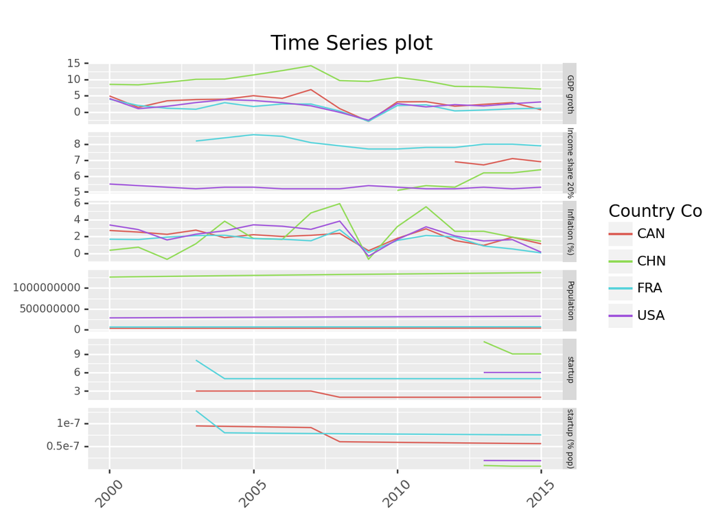

## Time Series plots with plotnine

- Using bars with `geom_col`

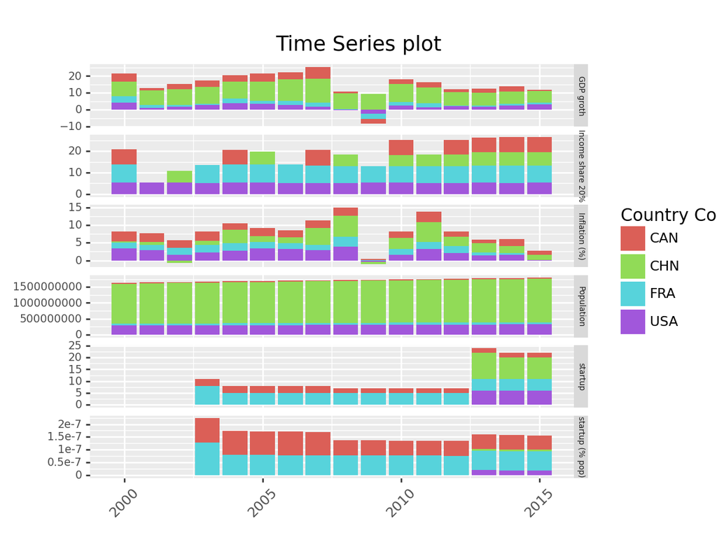

## Time Series plots with plotnine

- Changing colors

```python
(
  plt9.ggplot(data_time_series)
    + plt9.aes(x = "year", y = "Value", colour = "Country Code")
    + plt9.facet_grid(facets = ('Series','.'), scales = "free")
    + plt9.geom_line()
    + plt9.theme(axis_text_x=plt9.element_text(angle=45),
                 strip_text_y=plt9.element_text(size=5),
                 axis_text_y=plt9.element_text(size=7),
                 subplots_adjust={'right': 0.8})
    + plt9.labs(title = "Time Series plot", y = "", x = "")
    + plt9.scale_color_brewer(type="seq")
)
```

## Time Series plots with plotnine

- Changing colors

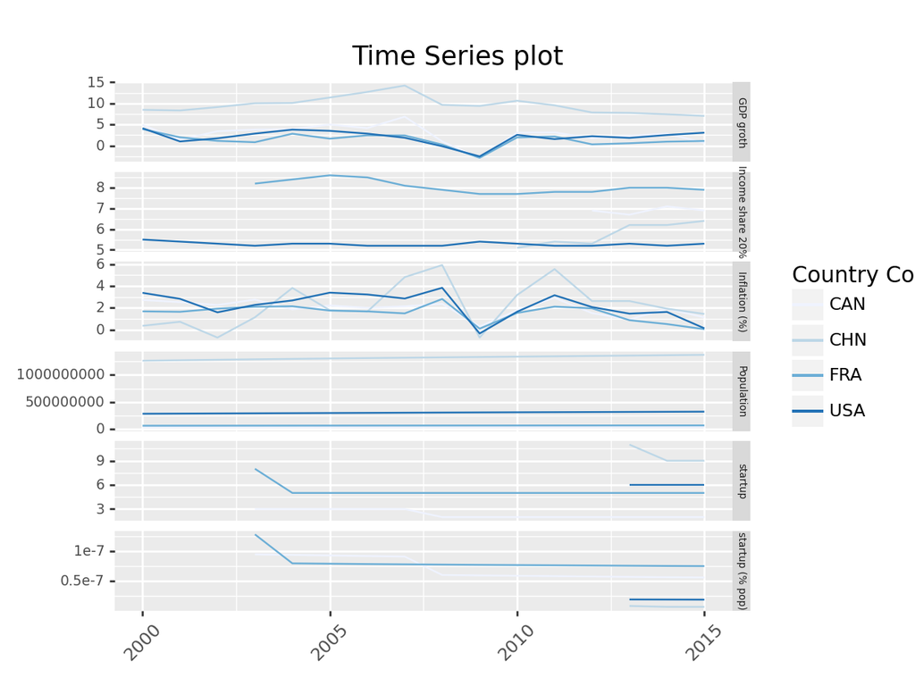

## Plotting advice

[figure not shown]

## Plotting advice

[figure not shown]

## Data viz

- A good data visualization is a very powerful tool!
- Visit [this website](https://vac-lshtm.shinyapps.io/ncov_tracker/) to get an idea of what powerful visualization is!
- Spend time doing graphs and play with the options!
- We’ll explore other data possibilities next lecture!

## Exercises

## Training to perform basic data visualization

Practice with `pandas`

1. Start back with the worldbank data where `NA` has been treated.
2. Using `matplotlib` or `plotnine`, present a boxplot of the four variables across countries and years (`plotnine` has the function `geom_boxplot`).
3. Using `matplotlib` or `plotnine`, present a histogram of the four variables across countries and years (`plotnine` has the function `geom_histogram`).
4. Do the same boxplots where the x-axis of each boxplot corresponds to years.
5. Using `plotnine`, do the same histograms with 4 panels, where each panel presents the histograms of 2000, 2007 and 2015.
6. Do you identify outliers from the plots? If so, identify in the data which countries contain these outliers.
7. Plot the time series of the fertility rate on one plot, where each color is a country. What is the graphical problem here?
8. Instead, do a barchart of the fertility rate in 2015, where the x-axis represents the country. What is the problem now?